# gClinBiomarker Package Overivew

Ning Leng, Alexey Pronin, Christina Rabe, Doug Kelkhoff, Kwame Okrah

2018-05-24

# 1 Overview

*gClinBiomarker* is an R package that allows users to easily perform biomarker analyses and generate high-quality figures and tables. It contains a set of functions covering essential biomarker analyses conducted in both oncology and non-oncology trials. It also provides an R markdown template that allows users to plug in their data set and generate a biomarker analysis report with “one-click”. The report contains demographics checking, biomarker property characterization, cutoff exploration (for continuous biomarkers), subgroup analysis, and longitudinal analysis. The package takes either VADs (AdAM) or a customized csv/data frame.

gClinBiomarker is built on top of the existing Baseline R package (biomarkers). The bulk of the work done on this package is on the back-end:

- streamline the original code,
- create robust documentation, and
- modularize the package for future extensions.

This vignette provides general guidelines of using gClinBiomarker package. Example workflows are also provided in the vignette, which cover essential biomarker analyses.

For advanced usage, more detailed examples can be found at:

https://github.roche.com/Rpackages/gClinBiomarker/blob/master/inst/doc/example-use-cases.pdf

pdf version of this document can be found at:

https://github.roche.com/Rpackages/gClinBiomarker/blob/master/inst/doc/package-overview.pdf

The Rmarkdown templates can be found at:

https://github.roche.com/lengn/gClinbiomarker_documents/tree/master/Markdown_templates

# 2 Install and load the package

To install this package from R, use install_github() function from the devtools package

In R, type:

```r
library(devtools)
install_github("RPackages/gClinBiomarker", host="https://github.roche.com/api/v3")
```

Before analysis can proceed, the gClinBiomarker package must be loaded into the working space:

```r
library(gClinBiomarker)
```

# 3 Input

## 3.1 Input requirement

Functions in gClinBiomarkers package take data frame as the input format. In this data frame, clinical data and biomarker data should all be included as columns. Rows are samples.

If only baseline biomarker analysis will be performed, the data frame should have one patient per row, without duplicated entries for any patient.

If longitudinal analysis will be performed, one patient may have multiple enteries for multiple visits.

Functions and may also be used to read in data in csv format and sas7bdat format.

## 3.2 Example data set: baseline only

An example data set is included in the package:

```r
head(input)
```

```
##   Patient.ID Sample.ID Arm Age Weight ECOG Sex Baseline.SLD        Country
## 1     PID001    SID001 TRT  40   61.0    0   F     550.4970 Western Europe
## 2     PID002    SID002 TRT  60   87.0    1   F     549.7751            USA
## 3     PID003    SID003 TRT  53   57.6    1   M     548.8829 Western Europe
## 4     PID004    SID004 TRT  44   57.0    0   F     549.6050            USA
## 5     PID005    SID005 TRT  49   72.5    2   F     551.5498          Other
## 6     PID006    SID006 TRT  62   76.0    0   M     549.2565          Other
##   CD8.ihc KRAS.mutant KRAS.exprs       OS      PFS  Response BEP OS.event
## 1       3      Mutant     171.25 9.691992 5.782341        PR   1        0
## 2       2   Wild Type       2.77 4.435318 1.412731        PD   1        1
## 3       3   Wild Type      61.82 9.691992 1.215606        PD   1        0
## 4       1      Mutant      71.51 1.905544 1.905544        PD   1        0
## 5      NA        <NA>         NA 2.628337 2.628337        SD   0        1
## 6       2      Mutant      44.63 4.829569 4.139630 NON CR/PD   1        0
##   PFS.event Lab_ontrt
## 1         0 28.993922
## 2         1  9.890427
## 3         1 26.896020
## 4         1  5.421392
## 5         1 14.741382
## 6         0 16.957035
```

```r
str(input)
```

```
## 'data.frame':    550 obs. of  19 variables:
##  $ Patient.ID  : chr  "PID001" "PID002" "PID003" "PID004" ...
##  $ Sample.ID   : chr  "SID001" "SID002" "SID003" "SID004" ...
##  $ Arm         : Factor w/ 2 levels "CTRL","TRT": 2 2 2 2 2 2 2 2 2 1 ...
##  $ Age         : int  40 60 53 44 49 62 70 49 62 45 ...
##  $ Weight      : num  61 87 57.6 57 72.5 76 46 69.3 65 54 ...
##  $ ECOG        : int  0 1 1 0 2 0 0 1 0 1 ...
##  $ Sex         : chr  "F" "F" "M" "F" ...
##  $ Baseline.SLD: num  550 550 549 550 552 ...
##  $ Country     : Factor w/ 3 levels "Other","USA",..: 3 2 3 2 1 1 3 3 3 1 ...
##  $ CD8.ihc     : num  3 2 3 1 NA 2 NA 1 NA NA ...
##  $ KRAS.mutant : Factor w/ 2 levels "Mutant","Wild Type": 1 2 2 1 NA 1 NA 2 NA NA ...
##  $ KRAS.exprs  : num  171.25 2.77 61.82 71.51 NA ...
##  $ OS          : num  9.69 4.44 9.69 1.91 2.63 ...
##  $ PFS         : num  5.78 1.41 1.22 1.91 2.63 ...
##  $ Response    : Factor w/ 6 levels "CR","NE","NON CR/PD",..: 5 4 4 4 6 3 4 3 4 6 ...
##  $ BEP         : num  1 1 1 1 0 1 0 1 0 0 ...
##  $ OS.event    : int  0 1 0 0 1 0 0 0 1 0 ...
##  $ PFS.event   : int  0 1 1 1 1 0 1 0 1 0 ...
##  $ Lab_ontrt   : num  28.99 9.89 26.9 5.42 14.74 ...
```

\newpage

# 4 Biomarker workflow

## 4.1 Continuous biomarker in a two-arm study with survival outcome

We use PFS as our primary endpoint, KRAS.exprs as the biomarker of interest.

### 4.1.1 Representativeness: Selection Bias of Biomarker Population

In this section, we are trying to answer the question: *Are biomarker evaluable population representative of the full population population?*

Key baseline demographics and prognostic characteristics (including stratification variables and any variables with known prognostic effect) and efficacy outcomes should be summarized by treatment groups and compared between biomarker evaluable population (BEP) and the full population. These analyses are conducted to investigate any potential selection bias associated with the availability of the biomarker (e.g. we may not get enough tissue for patients whose tumor size is small. Therefore they may be exlcuded from BEP).

#### 4.1.1.1 Check selection bias in terms of key clinical variables, between full population and BEP

Function can be used to perform selection bias checking of clinical variables. For example, if Age and Sex are two key clinical variables, we can perform the selection bias checking by:

```r
  SummaryVars(data=input, trt='Arm', subgroup='BEP', var=c('Sex','Age'),
       var.class=c('categorical','numeric'))
```

```
##                All(CTRL)    BEP(CTRL)     All(TRT)    BEP(TRT)
## Sex            ""           ""            ""          ""
## Total (non-NA) "182"        "81"          "368"       "176"
## NA's           "0"          "0"           "0"         "0"
## F              "89 (48.9%)" "39 (48.15%)" "184 (50%)" "90 (51.14%)"
## M              "93 (51.1%)" "42 (51.85%)" "184 (50%)" "86 (48.86%)"
## Age            ""           ""            ""          ""
## N              "182"        "81"          "368"       "176"
## Mean           "52.54"      "53.1"        "54.03"     "54.42"
## Median         "51.5"       "52"          "54"        "54"
## Min-Max        "27...85"    "32...85"     "30...89"   "33...89"
## NA's           "0"          "0"           "0"         "0"
```

function from knitr package may be used in Rmarkdown file for better table display:

```r
kable(
  SummaryVars(data=input, trt='Arm', subgroup='BEP', var=c('Sex','Age'),
       var.class=c('categorical','numeric'))
)
```

|  | All(CTRL) | BEP(CTRL) | All(TRT) | BEP(TRT) |
| --- | --- | --- | --- | --- |
| Sex |  |  |  |  |
| Total (non-NA) | 182 | 81 | 368 | 176 |
| NA’s | 0 | 0 | 0 | 0 |
| F | 89 (48.9%) | 39 (48.15%) | 184 (50%) | 90 (51.14%) |
| M | 93 (51.1%) | 42 (51.85%) | 184 (50%) | 86 (48.86%) |
| Age |  |  |  |  |
| N | 182 | 81 | 368 | 176 |
| Mean | 52.54 | 53.1 | 54.03 | 54.42 |
| Median | 51.5 | 52 | 54 | 54 |
| Min-Max | 27…85 | 32…85 | 30…89 | 33…89 |
| NA’s | 0 | 0 | 0 | 0 |

Here we specify the treatment column via parameter , and specify the BEP column via parameter . The comparision will be between BEP and the full population (BEP + nonBEP). If BEP vs. non BEP comparison is of interet, the user may specify parameter .

The clinical variables of interest can be specified via . Parameter can be used to specify class of the variable. Possible classes are “categorical”,“numeric”,“ordered.factor”. If var.class is not specified, the program will define the variable class based on class of the column (class()). Note that for ordinal variable whose levels are numbers, the column need to be converted to ordered factor. Otherwise it will be treated as continuous variable.

#### 4.1.1.2 Check whether the clinical outcome in BEP is comparable to the full population

Function can be used to compare survival outcome in BEP vs. the full population:

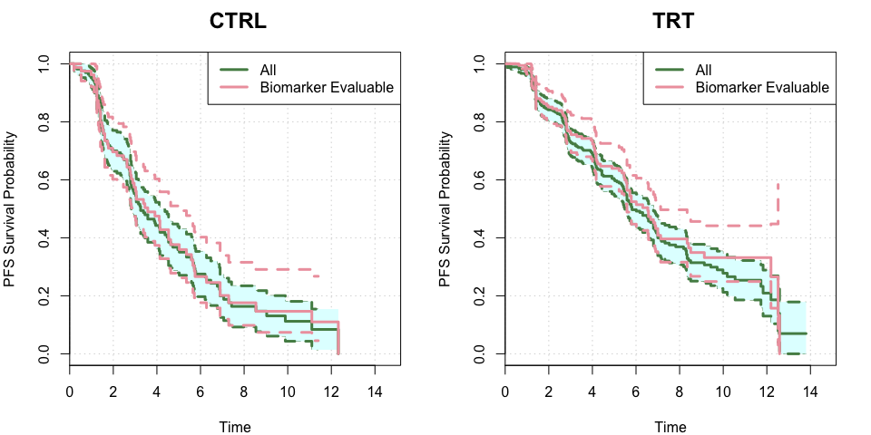

```r
CompareKM(data=input,tte='PFS', cen='PFS.event',trt='Arm', bep='BEP')
```

By default, the KM curve and 95% CI will be plotted for each arm. The BEP KM curve is expected to be within the full population confidence bands.

#### 4.1.1.3 Examine whether the prognostic/predictive/null trend of key clinical variables holds in BEP

Function PlotTanForestMulti may be used to examine whether any of the key clinical variables show predictive trend in BEP:

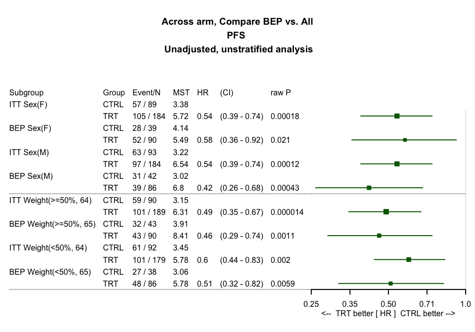

```r
PlotTabForestMulti(data=input,
                                  outcome.class="survival",
                                  outcome.var=c("PFS","PFS.event"),
                                  trt="Arm",
                                  var=c("Sex","Weight"),
                   bep="BEP",bep.indicator=1, compare.bep.itt=TRUE
                   )
```

From the plot above, we can see that variable Sex doesn’t show a predictive trend in full population (similar trt/ctrl HR in male and female group). However, in BEP the variable Sex has numerically smaller trt/ctrl HR in Male group. Although from the SummaryVars() result, the percentages of Male are comparable between full population and BEP, it is still possible that the male patients have better clinical outcome than the female group. This is likely due to some selection bias that we weren’t be able to capture in previous steps (e.g. unmeasured variable). In downstream analyses, if the biomarker subgroup also show a predictive effect, we will need to check that whether it is confounded by Sex.

#### 4.1.1.4 Compare treatment effect estimation in full population and in BEP, adjusted for key clinical variables

```r
input.bep <- subset(input, BEP==1) # dataset with only BEP samples

kable(
  CoxTab(data=input,tte="PFS", cens="PFS.event",  var='Arm',
       var.class="categorical"),
caption="full population, unadjusted"
)
```

full population, unadjusted

|  | HR | CI.low | CI.high | p-value | n.trt | n.ref |
| --- | --- | --- | --- | --- | --- | --- |
| Arm (TRT/CTRL) | 0.54 | 0.43 | 0.67 | 0.000000078 | 368 | 182 |

```r
kable(
  CoxTab(data=input,tte="PFS", cens="PFS.event",  var=c('Arm','Sex',"Weight"),
       var.class=c("categorical","categorical","numeric")),
caption="full population, adjusted for Sex, Weight"
)
```

full population, adjusted for Sex, Weight

|  | HR | CI.low | CI.high | p-value | n.trt | n.ref |
| --- | --- | --- | --- | --- | --- | --- |
| Arm (TRT/CTRL) | 0.53 | 0.42 | 0.67 | 0.000000056 | 368 | 182 |
| Sex (M/F) | 0.9 | 0.72 | 1.12 | 0.35 | 277 | 273 |
| Weight | 1 | 0.99 | 1 | 0.39 |  |  |

```r
kable(
  CoxTab(data=input.bep,tte="PFS", cens="PFS.event",  var='Arm',
       var.class="categorical"),
caption="BEP, unadjusted"
)
```

BEP, unadjusted

|  | HR | CI.low | CI.high | p-value | n.trt | n.ref |
| --- | --- | --- | --- | --- | --- | --- |
| Arm (TRT/CTRL) | 0.49 | 0.36 | 0.69 | 0.000031 | 176 | 81 |

```r
kable(
  CoxTab(data=input.bep,tte="PFS", cens="PFS.event",  var=c('Arm','Sex',"Weight"),
       var.class=c("categorical","categorical","numeric")),
caption="BEP, adjusted for Sex, Weight"
)
```

BEP, adjusted for Sex, Weight

|  | HR | CI.low | CI.high | p-value | n.trt | n.ref |
| --- | --- | --- | --- | --- | --- | --- |
| Arm (TRT/CTRL) | 0.48 | 0.34 | 0.67 | 0.000014 | 176 | 81 |
| Sex (M/F) | 0.78 | 0.56 | 1.08 | 0.13 | 128 | 129 |
| Weight | 0.99 | 0.98 | 1 | 0.12 |  |  |

If any selection bias is suspected, the user may consider to stratify for the imbalanced factor in downstream analysis (e.g. unstratified analysis as primary analysis and stratified analysis as sensitivity analysis).

### 4.1.2 Biomarker property and its association to clinical variables

Before performing cutoff exploraotry analysis, it is important to check a biomarker’s property. For example, whether this biomarker has a bi-modal or multi modal distribution - if so, this biomarker may has natural cutoff.  
Relationship between the biomarker and key demographic and prognostic variables should also be investigated using bivariate plots. Prognostic property of the biomarker should also be assessed, by estimates of the clinical efficacy in the control arm.

The function could be used to generate single variate plot for biomaker and clinical covariates. It can also be used to generate bi-variate plots to investigate biomarker-clinical variable relationship.

#### 4.1.2.1 Biomarker property and relationship to clinical variable

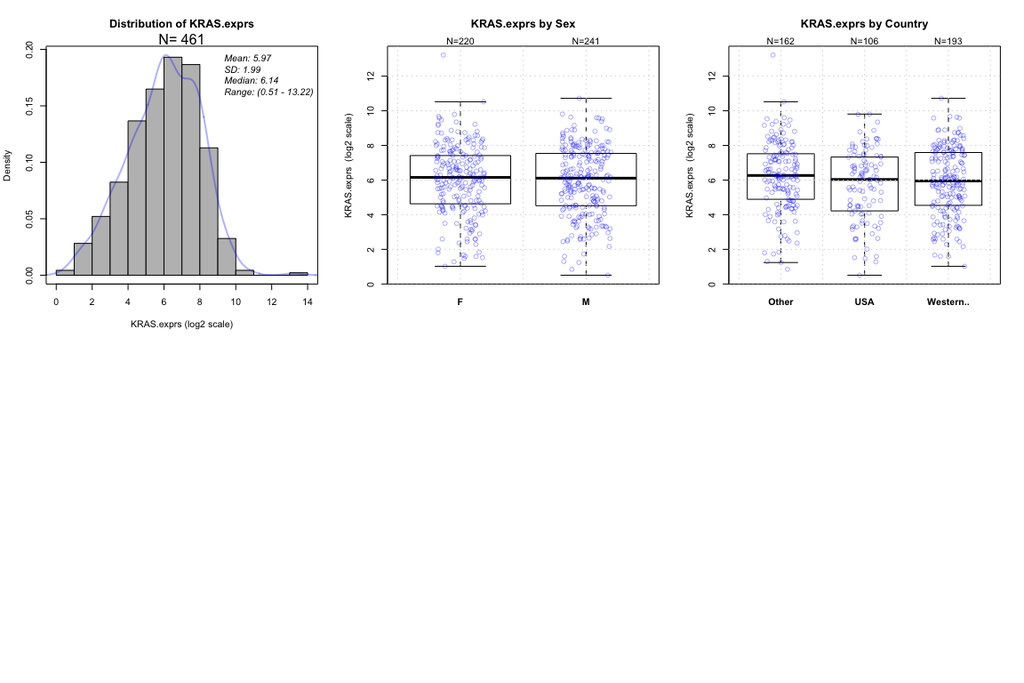

```r
PlotProperty(data=input, biomarker.var="KRAS.exprs", biomarker.class="numeric",
             var=c("Sex", "Country"), var.class=c("categorical", "categorical"),
             log2=TRUE, par.param = list(mfrow=c(2,3)))
```

#### 4.1.2.2 Whether the biomarker show within-arm trend

Function can be used to investigate whether the biomarker shows within-arm trend:

```
## Some NAs in var column, will define the non NA entries as BEP
```

```
## only 1 arm; show.itt is set to FALSE
```

```
## only 1 arm; show.bep is set to FALSE
```

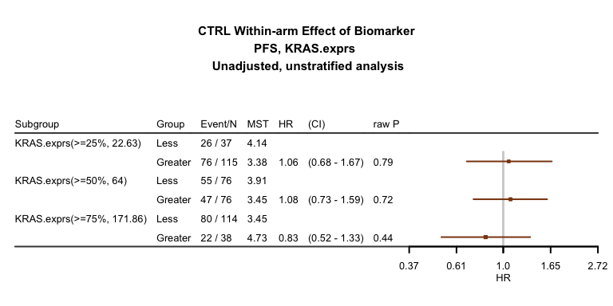

```r
input.ctrl <- subset(input, Arm=="CTRL") ## Data with only ctrl samples
res.multicut.ctrl <- PlotTabForestBiomarker(data=input.ctrl,
                                  outcome.class="survival",
                                  outcome.var=c("PFS","PFS.event"),
                                  var="KRAS.exprs",
                                  var.class="numeric",
                                  percentile.cutoff=c(.25,.5,.75), main.prefix="CTRL",
                                  greater=TRUE, less=FALSE)
```

```
## Some NAs in var column, will define the non NA entries as BEP
```

```
## only 1 arm; show.itt is set to FALSE
```

```
## only 1 arm; show.bep is set to FALSE
```

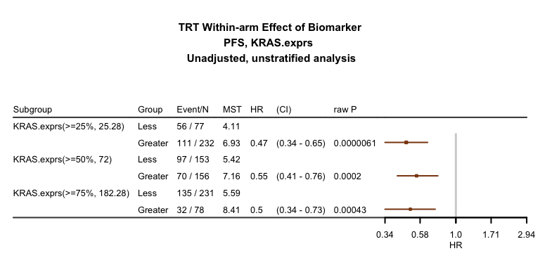

```r
input.trt <- subset(input, Arm=="TRT") ## Data with only trt samples
res.multicut.trt <- PlotTabForestBiomarker(data=input.trt,
                                  outcome.class="survival",
                                  outcome.var=c("PFS","PFS.event"),
                                  var="KRAS.exprs",
                                  var.class="numeric",
                                  percentile.cutoff=c(.25,.5,.75), main.prefix="TRT",
                                  greater=TRUE, less=FALSE)
```

We first get dataset input.ctrl and input.trt, which only contains patients in ctrl arm and trt arm, respectively. In function , time to event variable and censoring variable need to be specified via . The biomarker variable can be specified via . By specifying as and specifying TRUE+, the program calculates within-arm HR of biomarker >= 25% vs <25% group, biomarker >= 50% vs <50% group, and biomarker >= 75% vs <75% group.

In ctrl arm, patients who have expression >= 75% have slightly better PFS - >= 75% vs <75% HR is 0.83, and the median PFS is slightly higher in >= 75% group (4.73) vs <75% (3.45).

In trt arm, within-arm trend is seen in all three comparisons - for all 3 cutoffs, patients with higher expression have longer PFS than patients with low expression. The biomarker high vs. low HR are all around 0.5.

If strong within-arm effect is seen in both arms, the biomarker may be prognostic but not predictive.

If stratified or adjusted analyses are of interest, they can be specified via parameters and .

### 4.1.3 Seeking for predictive trend: Biomarker cutoff exploration/selection

Example codes in this section can be used to examine multiple candidate cutoffs for a continuous biomarker. The need for cut-off determination should be rooted in the development strategy. In general, an exhaustive search looking at all possible cut-off values is not recommended for decision making. Over-optimized cutoff using one set of clinical data may lead to hard-to-reproduce results. When determining a cutoff, biomarker property should be considered - e.g. cut at a low-dense point may be more robust to population shift. The cutoff selection should also fit the program’s stratigitic considerations. There is always a prevalence-effect size trade-off, inputs from multiple functions are needed - for example whether the team is willing to take more risk in PTS (high prevalence, weaker signal) or the team is willing to target at smaller population (lower prevalence, stronger signal)

#### 4.1.3.1 Try different cutoffs - look for consistent trend

Function can also be used to investigate whether the biomarker is predictive across arm. To perform cross-arm analysis, parameter needs to be specified. By specifying ane , trt/ctrl HR of biomarker >= 25% group, biomarker >= 50% group, and biomarker >= 75% group are calculated:

```
## Some NAs in var column, will define the non NA entries as BEP
```

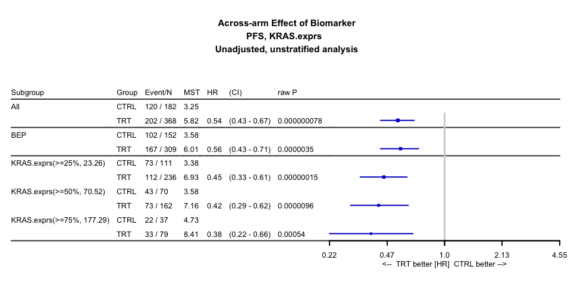

```r
res.multicut <- PlotTabForestBiomarker(data=input,
                                  outcome.class="survival",
                                  outcome.var=c("PFS","PFS.event"),
                                  trt="Arm",
                                  var="KRAS.exprs",
                                  var.class="numeric",
                                  percentile.cutoff=c(.25,.5,.75),
                                  greater=TRUE, less=FALSE,
                                  show.itt=TRUE, show.bep=TRUE)
```

#### 4.1.3.2 Estimations within non-overlapping bins

Function can also be used to calculate trt/ctrl HR within percentile bins. For example, by specifying , trt/ctrl HR of biomarker 0-25% group, 25-50% group, 50-75% group,and 75-100% group are calculated:

```
## Some NAs in var column, will define the non NA entries as BEP
```

```
## within.bin is TRUE, greater and less will be ignored
```

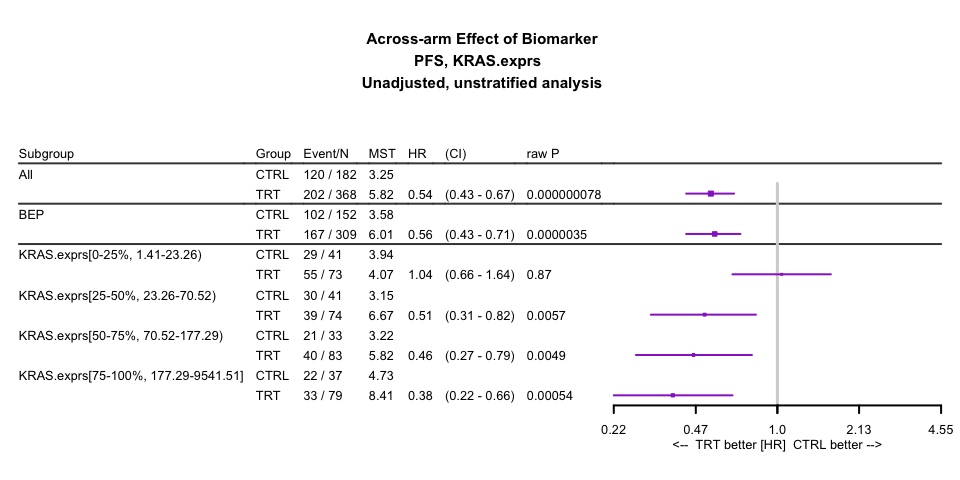

```r
res.withinbin <- PlotTabForestBiomarker(data=input,
                                  outcome.class="survival",
                                  outcome.var=c("PFS","PFS.event"),
                                  trt="Arm",
                                  var="KRAS.exprs",
                                  var.class="numeric",
                                  percentile.cutoff=c(.25,.5,.75),
                                  within.bin=TRUE,
                                  show.itt=TRUE, show.bep=TRUE)
```

#### 4.1.3.3 Estimations within overlapped sliding windows - STEPP plot

STEPP refers to Subgroup Treatment Effect Pattern Plot and it investigates relationship between biomarker and treatment effect. Only continuous biomarkers are suitable for STEPP analysis. STEPP performs treatment effect estimation on overlapping subsets of patients defined according to the biomarker level. The default setting of run.STEPP slides subgroup windows by 5% for each step and the subgroup size is 25% of the whole population.

A monotone trend is expected to be seen for an ideal biomarker.

```
## some NA in var column, will ignore NA entries
```

[figure not shown]

```r
stepp.out <- PlotSTEPP(data = input,
          outcome.var = c("PFS", "PFS.event"),
          outcome.class = "survival",
          trt = "Arm",
          var = "KRAS.exprs",
          placebo.code = "CTRL",
          active.code = "TRT"
)
```

Here we can see the trt/ctrl HR decreases as the biomarker expression increases.

### 4.1.4 Biomarker subgroup analysis (using selected cutoff)

When a cutoff is selected, the following functions can be used to perfrom subgroups analysis. Suppose that we decided to use 100 as cutoff.

#### 4.1.4.1 Estimations within each subgroup

function can again be used to estimate the treatment effect in biomarker subgroups. Here given that we have a numerical cutoff, it can be specified using parameter . And can be left as NULL.

```
## Some NAs in var column, will define the non NA entries as BEP
```

```
## within.bin is TRUE, greater and less will be ignored
```

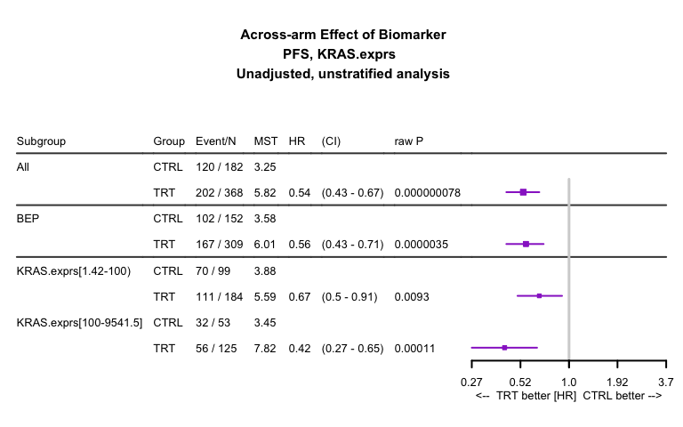

```r
res.subgroups.cut <- PlotTabForestBiomarker(data=input,
                                  outcome.class="survival",
                                  outcome.var=c("PFS","PFS.event"),
                                  trt="Arm",
                                  var="KRAS.exprs",
                                  var.class="numeric",
                                  percentile.cutoff=NULL,
                                  numerical.cutoff=100, within.bin=TRUE,
                                  show.itt=TRUE, show.bep=TRUE)
```

This can also be done by converting the continuous marker to a binary variable:

```
## Some NAs in var column, will define the non NA entries as BEP
```

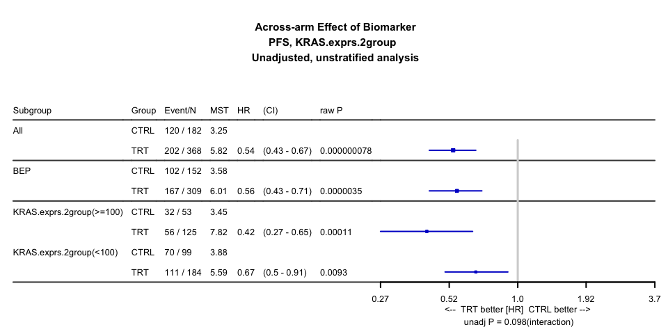

```r
input$KRAS.exprs.2group <- ifelse(input$KRAS.exprs >= 100, ">=100","<100")
input$KRAS.exprs.2group <- factor(input$KRAS.exprs.2group, levels=c(">=100","<100")) # ">=100" as Dx+
res.subgroups.bi <- PlotTabForestBiomarker(data=input,
                                  outcome.class="survival",
                                  outcome.var=c("PFS","PFS.event"),
                                  trt="Arm",
                                  var="KRAS.exprs.2group",
                                  var.class="categorical",
                                  show.itt=TRUE, show.bep=TRUE)
```

#### 4.1.4.2 KM curves

Function can be used to generate the KM curves of biomarker subgroups:

```
## more than one elements in 'var', trt parameter will be ignored
```

```
## 'varlist' is specified, trt and var parameters will be ignored
```

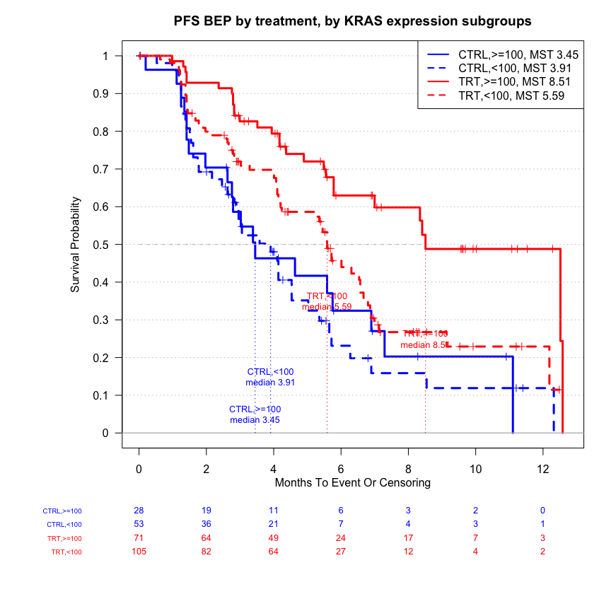

```
## [1] ""
```

```r
PlotKM(data=input, tte="PFS",cen="PFS.event", bep="BEP",
             main="PFS BEP by treatment, by KRAS expression subgroups",
             var=c("Arm","KRAS.exprs.2group"), legend.loc="topright",
       plot.median=TRUE)
```

#### 4.1.4.3 Check whether biomarker subgroup is confounded with key clinical variables

Functions and can again be used to check whether the biomarker subgroup is confounded with clinical variable. Using sex variable as an exmaple, instead of checking whether the F/M percentage is comparable in the full population vs. BEP, here we check the F/M percentage is comparable in biomarker high and low group. To perform such analysis we can specify as , and specify . By doing so the program will compare the “>=100” group vs. others.

```r
input.bep <- subset(input, BEP==1)
kable(
SummaryVars(data=input.bep,trt='Arm', subgroup='KRAS.exprs.2group', var=c('Sex'),
       var.class="categorical", subgroup.indicator=">=100",compare.subgroup=TRUE, subgroup.name="exprs")
)
```

|  | exprs_>=100(CTRL) | exprs_<100(CTRL) | exprs_>=100(TRT) | exprs_<100(TRT) |
| --- | --- | --- | --- | --- |
| Sex |  |  |  |  |
| Total (non-NA) | 28 | 53 | 71 | 105 |
| NA’s | 0 | 0 | 0 | 0 |
| F | 15 (53.57%) | 24 (45.28%) | 36 (50.7%) | 54 (51.43%) |
| M | 13 (46.43%) | 29 (54.72%) | 35 (49.3%) | 51 (48.57%) |

function could be used to look at treatment effect in smaller subgroups defined by both biomarker and clinical variables. For example, if we are interested in the trt/ctrl HR in following groups: biomarker high Male; biomarker high female; biomarker low male; biomarker low female, etc. We may specify as the biomarker variable, and as the clinical variables of interest. By setting and , the program will calculate the summary statistics within each subgroup. For numerical clinical variable, it will be dichotomized by its median.

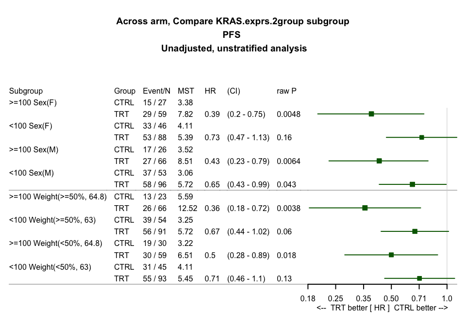

```r
res.subgroup.cov <- PlotTabForestMulti(data=input,
                                  outcome.class="survival",
                                  outcome.var=c("PFS","PFS.event"),
                                  trt="Arm",
                                  var=c("Sex","Weight"),
                   compare.bep.itt=FALSE,
                   compare.subgroup=TRUE,
                   subgroup="KRAS.exprs.2group"
                   )
```

In this case, no treatment effect difference is observed between the Female vs. Male subgroups (as well as weight high & low).

\newpage

## 4.2 Continuous biomarker in a single-arm study with survival outcome

We generate a data set with only patients from the treatment arm to mimic the case of single arm study:

```r
input.trt <- subset(input, Arm=="TRT")
```

### 4.2.1 Representativeness: Selection Bias of Biomarker Population

#### 4.2.1.1 Check selection bias in terms of key clinical variables, between the full population and BEP

```r
kable(
  SummaryVars(data=input.trt, trt=NULL, subgroup='BEP', var=c('Age','Sex'),
       var.class=c('numeric','categorical'))
)
```

|  | All | BEP |
| --- | --- | --- |
| Age |  |  |
| N | 368 | 176 |
| Mean | 54.03 | 54.42 |
| Median | 54 | 54 |
| Min-Max | 30…89 | 33…89 |
| NA’s | 0 | 0 |
| Sex |  |  |
| Total (non-NA) | 368 | 176 |
| NA’s | 0 | 0 |
| F | 184 (50%) | 90 (51.14%) |
| M | 184 (50%) | 86 (48.86%) |

#### 4.2.1.2 Check whether the clinical outcome in BEP is comparable to the full population

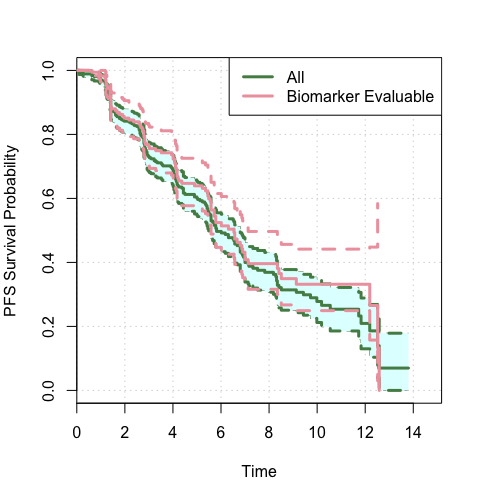

```r
CompareKM(data=input.trt,tte='PFS', cen='PFS.event',trt=NULL, bep='BEP')
```

#### 4.2.1.3 Examine whether the prognostic/null trend of key clinical variables holds in BEP

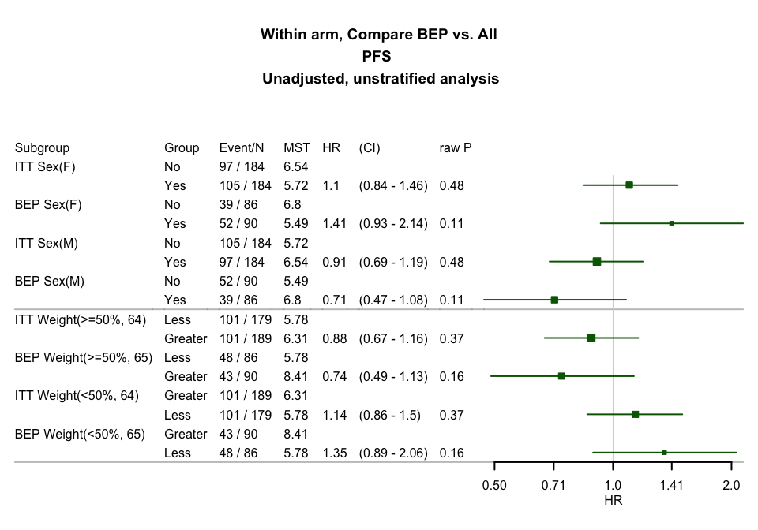

```r
PlotTabForestMulti(data=input.trt,
                                  outcome.class="survival",
                                  outcome.var=c("PFS","PFS.event"),
                                  trt=NULL,
                                  var=c("Sex","Weight"),
                   bep="BEP",bep.indicator=1, compare.bep.itt=TRUE
                   )
```

```r
input.trt.bep <- subset(input.trt, BEP==1) # dataset with only BEP samples

kable(
  CoxTab(data=input.trt,tte="PFS", cens="PFS.event",  var=c('Sex',"Weight"),
       var.class=c("categorical","numeric")),
caption="the full population, model of Sex, Weight"
)
```

the full population, model of Sex, Weight

|  | HR | CI.low | CI.high | p-value | n.trt | n.ref |
| --- | --- | --- | --- | --- | --- | --- |
| Sex (M/F) | 0.91 | 0.69 | 1.2 | 0.49 | 184 | 184 |
| Weight | 1 | 0.99 | 1 | 0.33 |  |  |

```r
kable(
  CoxTab(data=input.trt.bep,tte="PFS", cens="PFS.event",  var=c('Sex',"Weight"),
       var.class=c("categorical","numeric")),
caption="BEP, model of Sex, Weight"
)
```

BEP, model of Sex, Weight

|  | HR | CI.low | CI.high | p-value | n.trt | n.ref |
| --- | --- | --- | --- | --- | --- | --- |
| Sex (M/F) | 0.7 | 0.46 | 1.06 | 0.09 | 86 | 90 |
| Weight | 0.99 | 0.97 | 1 | 0.094 |  |  |

### 4.2.2 Biomarker property and association with clinical variables

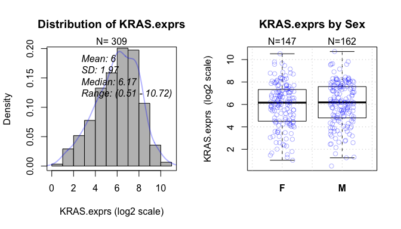

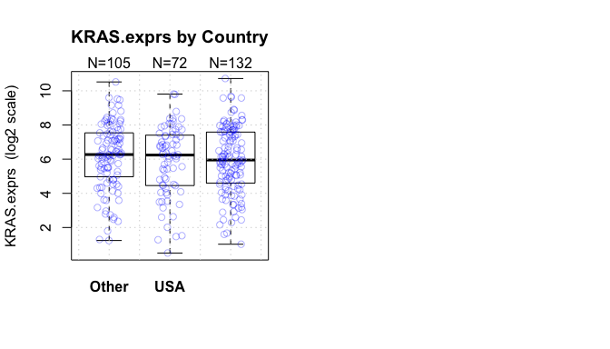

```r
PlotProperty(data=input.trt, biomarker.var="KRAS.exprs", biomarker.class="numeric",
             var=c("Sex", "Country"), var.class=c("categorical", "categorical"),
             log2=TRUE, par.param = list(mfrow=c(1,2)))
```

### 4.2.3 Biomarker cutoff exploration/selection

#### 4.2.3.1 Try different cutoffs - look for consistent trend

```
## Some NAs in var column, will define the non NA entries as BEP
```

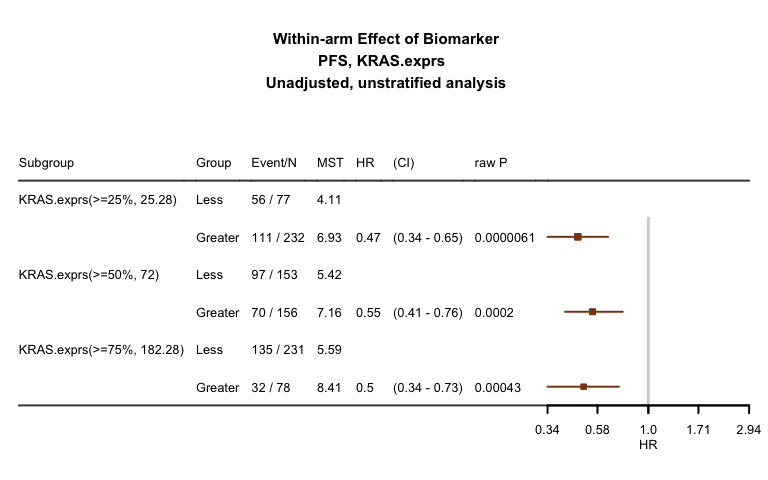

```r
res.multicut <- PlotTabForestBiomarker(data=input.trt,
                                  outcome.class="survival",
                                  outcome.var=c("PFS","PFS.event"),
                                  trt=NULL,
                                  var="KRAS.exprs",
                                  var.class="numeric",
                                  percentile.cutoff=c(.25,.5,.75),
                                  greater=TRUE, less=FALSE,
                                  show.itt=FALSE, show.bep=FALSE)
```

Within-bin analysis and STEPP are not available in single-arm analysis.

### 4.2.4 Biomarker subgroup analysis (using selected cutoff)

#### 4.2.4.1 Subgroup analysis

Suppose the proposed cutoff is 100

```
## Some NAs in var column, will define the non NA entries as BEP
```

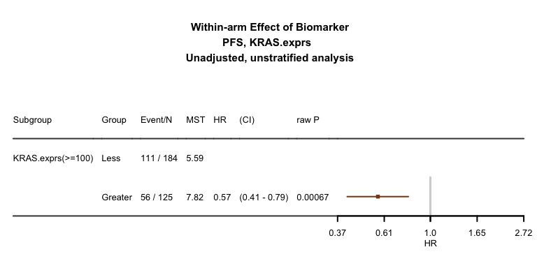

```r
res.subgroups.cut <- PlotTabForestBiomarker(data=input.trt,
                                  outcome.class="survival",
                                  outcome.var=c("PFS","PFS.event"),
                                  trt=NULL,
                                  var="KRAS.exprs",
                                  var.class="numeric",
                                  percentile.cutoff=NULL,
                                  numerical.cutoff=100,
                                  greater=TRUE,less=FALSE,
                                  show.itt=FALSE, show.bep=FALSE)
```

This can also be done by converting the continous marker to a binary variable

```
## Some NAs in var column, will define the non NA entries as BEP
```

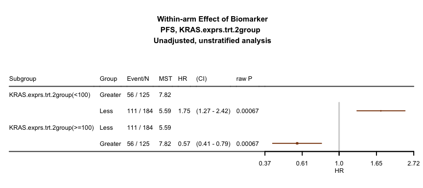

```r
input.trt$KRAS.exprs.trt.2group <- ifelse(input.trt$KRAS.exprs >= 100, ">=100","<100")
input.trt$KRAS.exprs.2group <- factor(input.trt$KRAS.exprs.2group, levels=c(">=100","<100")) # ">=100" as Dx+

res.subgroups.bi <- PlotTabForestBiomarker(data=input.trt,
                                  outcome.class="survival",
                                  outcome.var=c("PFS","PFS.event"),
                                  trt=NULL,
                                  var="KRAS.exprs.trt.2group",
                                  var.class="categorical",
                                  show.itt=FALSE, show.bep=FALSE)
```

#### 4.2.4.2 KM curves

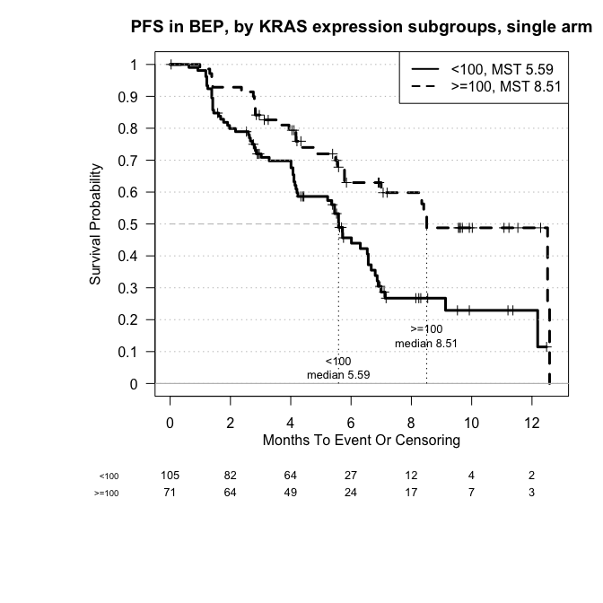

```
## [1] ""
```

```r
PlotKM(data=input.trt, tte="PFS",cen="PFS.event", bep="BEP",
             main="PFS in BEP, by KRAS expression subgroups, single arm",
             var=c("KRAS.exprs.trt.2group"), legend.loc="topright",
       plot.median=TRUE)
```

#### 4.2.4.3 Check whether biomarker subgroup is confounded with clinical variables

```r
input.trt.bep <- subset(input.trt, BEP==1)
kable(
SummaryVars(data=input.trt.bep,trt=NULL, subgroup='KRAS.exprs.2group', var=c('Sex'),
       var.class="categorical", subgroup.indicator=">=100",compare.subgroup=TRUE, subgroup.name="exprs")
)
```

|  | exprs_>=100 | exprs_<100 |
| --- | --- | --- |
| Sex |  |  |
| Total (non-NA) | 71 | 105 |
| NA’s | 0 | 0 |
| F | 36 (50.7%) | 54 (51.43%) |
| M | 35 (49.3%) | 51 (48.57%) |

\newpage

## 4.3 Categorical biomarker with survival outcome

### 4.3.1 Two-arm study

Analyses in section 4.1 can also be applied to categorial biomarker, except the cutoff exploration part (section 4.1.3).

For example, for categorical biomarker KRAS.mutant, the subgroup analysis can be performed using the function:

```
## Some NAs in var column, will define the non NA entries as BEP
```

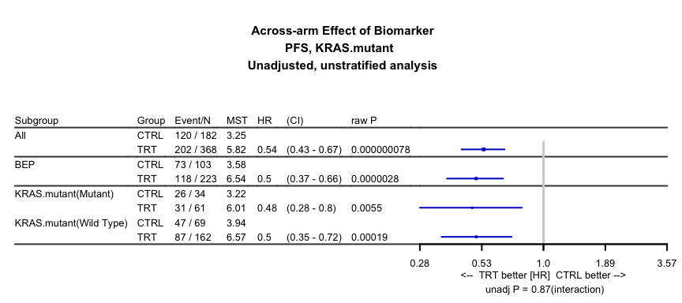

```r
res.subgroups.cat <- PlotTabForestBiomarker(data=input,
                                  outcome.class="survival",
                                  outcome.var=c("PFS","PFS.event"),
                                  trt="Arm",
                                  var="KRAS.mutant",
                                  var.class="categorical",
                                  show.itt=TRUE, show.bep=TRUE)
```

The forest plot above provides HR estimates across two arms

### 4.3.2 Single-arm study

Similarly, most functions in section 4.2 can be applied to categorical biomarker analysis (except the cutoff exploration part in section 4.2.3). For example, taking the data set which only contains patients from treatment arm:

```
## Some NAs in var column, will define the non NA entries as BEP
```

```
## only 1 arm; show.itt is set to FALSE
```

```
## only 1 arm; show.bep is set to FALSE
```

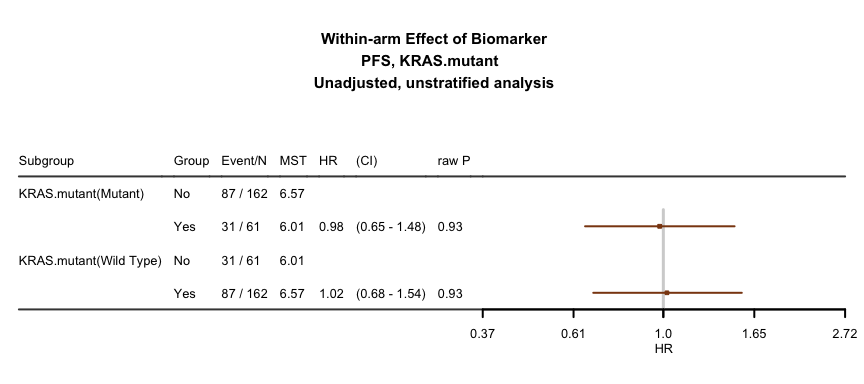

```r
res.subgroups.cat <- PlotTabForestBiomarker(data=input.trt,
                                  outcome.class="survival",
                                  outcome.var=c("PFS","PFS.event"),
                                  trt=NULL,
                                  var="KRAS.mutant",
                                  var.class="categorical")
```

\newpage

## 4.4 Categorical outcome (e.g. response)

### 4.4.1 Check selection bias in terms of key clinical variables, between full population and BEP

Majority of functions from section 4.1.1 can be directly applied on analyses of categorical endpoints.

Function in section 4.1.1 can still be used to perform selection bias checking of clinical variables. To check whether clinical outcome in BEP is comparable to the full population, user can use function when the clinical outcome is response assessment. The parameter may be used to define order of the levels.

```
## entries with missing outcome.var are removed! 524 entries left
```

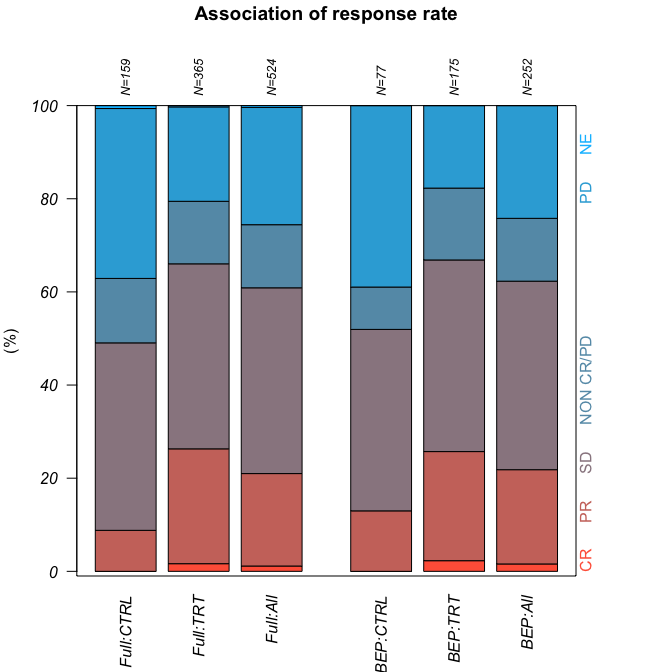

```r
Rsp.out <- PlotRspBar(data=input, outcome.var="Response", binary=FALSE,
rsp.levels=c("CR", "PR","SD","NON CR/PD", "PD","NE"),trt="Arm",
compare.bep.itt=TRUE, bep = "BEP")
```

The summary statistics can be obtained by:

```r
kable(Rsp.out$count,caption="count")
```

count

|  | CR | PR | SD | NON CR/PD | PD | NE |
| --- | --- | --- | --- | --- | --- | --- |
| Full:CTRL | 0 | 14 | 64 | 22 | 58 | 1 |
| Full:TRT | 6 | 90 | 145 | 49 | 74 | 1 |
| Full:All | 6 | 104 | 209 | 71 | 132 | 2 |
| BEP:CTRL | 0 | 10 | 30 | 7 | 30 | 0 |
| BEP:TRT | 4 | 41 | 72 | 27 | 31 | 0 |
| BEP:All | 4 | 51 | 102 | 34 | 61 | 0 |

```r
kable(round(Rsp.out$perc,2), caption="percentage")
```

percentage

|  | CR | PR | SD | NON CR/PD | PD | NE |
| --- | --- | --- | --- | --- | --- | --- |
| Full:CTRL | 0.00 | 0.09 | 0.40 | 0.14 | 0.36 | 0.01 |
| Full:TRT | 0.02 | 0.25 | 0.40 | 0.13 | 0.20 | 0.00 |
| Full:All | 0.01 | 0.20 | 0.40 | 0.14 | 0.25 | 0.00 |
| BEP:CTRL | 0.00 | 0.13 | 0.39 | 0.09 | 0.39 | 0.00 |
| BEP:TRT | 0.02 | 0.23 | 0.41 | 0.15 | 0.18 | 0.00 |
| BEP:All | 0.02 | 0.20 | 0.40 | 0.13 | 0.24 | 0.00 |

To plot counts instead of percentage, one can specify the parameter to TRUE:

```
## entries with missing outcome.var are removed! 524 entries left
```

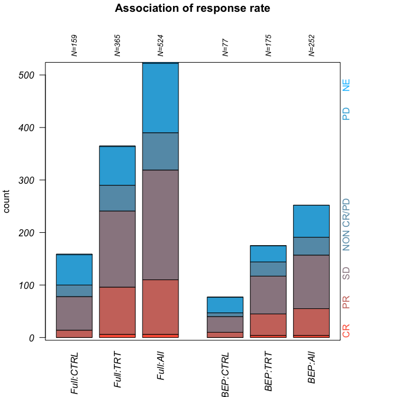

```r
PlotRspBar(data=input, outcome.var="Response", binary=FALSE,
rsp.levels=c("CR", "PR","SD","NON CR/PD", "PD","NE"),trt="Arm",
compare.bep.itt=TRUE, bep = "BEP", plot.count=TRUE)
```

To summarize the response into two classes - responder vs. non-responder, user may set the parameter to TRUE. Parameter () can be used to define levels to be considered as responder (non-responder). Patients whose response outcome don’t fall into these defined levels will be elminated from the analysis.

```
## entries with missing outcome.var are removed! 524 entries left
```

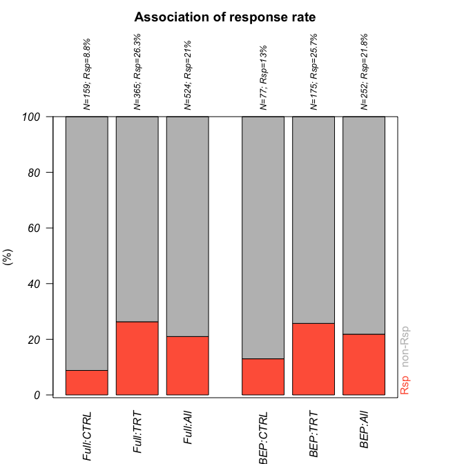

```r
Rsp.out.2 <- PlotRspBar(data=input, outcome.var="Response", binary=TRUE,
rsp.response = c("CR","PR"),
rsp.nonresponse = c("SD", "PD","NON CR/PD","NE"),trt="Arm",
compare.bep.itt=TRUE, bep = "BEP")
```

The summary statistics can be obtained by:

```r
kable(Rsp.out.2$count,caption="count")
```

count

|  | Rsp | non-Rsp |
| --- | --- | --- |
| Full:CTRL | 14 | 145 |
| Full:TRT | 96 | 269 |
| Full:All | 110 | 414 |
| BEP:CTRL | 10 | 67 |
| BEP:TRT | 45 | 130 |
| BEP:All | 55 | 197 |

```r
kable(round(Rsp.out.2$perc,2), caption="percentage")
```

percentage

|  | Rsp | non-Rsp |
| --- | --- | --- |
| Full:CTRL | 0.09 | 0.91 |
| Full:TRT | 0.26 | 0.74 |
| Full:All | 0.21 | 0.79 |
| BEP:CTRL | 0.13 | 0.87 |
| BEP:TRT | 0.26 | 0.74 |
| BEP:All | 0.22 | 0.78 |

To plot counts instead of percentage, one can specify the parameter to TRUE:

```
## entries with missing outcome.var are removed! 524 entries left
```

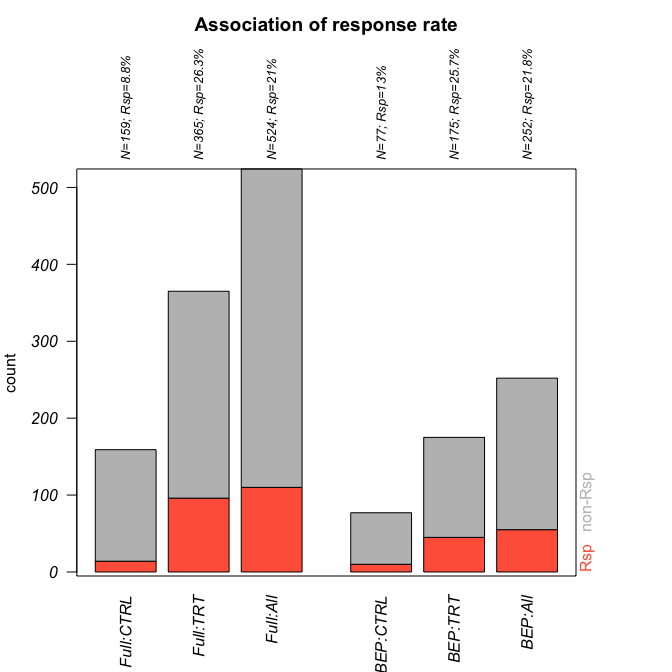

```r
PlotRspBar(data=input, outcome.var="Response", binary=TRUE,
rsp.response = c("CR","PR"),
rsp.nonresponse = c("SD", "PD","NON CR/PD","NE"),trt="Arm",
compare.bep.itt=TRUE, bep = "BEP", plot.count = TRUE)
```

### 4.4.2 Continuous biomarker in a two-arm study

Most of functions in workflow in section 4.1 may be used in analyses of continuous biomarker in a 2-arm study with categorical response. The following sections show examples of categorical-response specific use cases

#### 4.4.2.1 Check within-arm trend

To check the within-arm trend associated with categorical outcome, user may use the same function as in section 4.1.2.2. Instead of specifying outcome.class as “survival”, user can specify outcome.class as “binary”.

```
## Covariate adjustment and stratification are not supported for binary outcome
```

```
## Some NAs in var column, will define the non NA entries as BEP
```

```
## only 1 arm; show.itt is set to FALSE
```

```
## only 1 arm; show.bep is set to FALSE
```

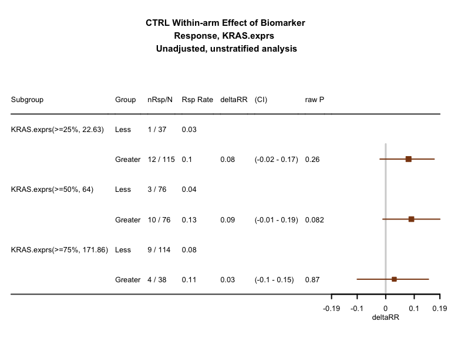

```r
input.ctrl <- subset(input, Arm=="CTRL") ## Data with only ctrl samples
res.multicut.ctrl <- PlotTabForestBiomarker(data=input.ctrl,
                                  outcome.class=c("binary"),
                                  outcome.var=c("Response"),
                                  rsp.cat = TRUE,
                                  rsp.response = c("CR","PR"),
                                  rsp.nonresponse = c("SD", "PD","NON CR/PD","NE",NA),
                                  var="KRAS.exprs",
                                  var.class="numeric",
                                  percentile.cutoff=c(.25,.5,.75), main.prefix="CTRL",
                                  greater=TRUE, less=FALSE)
```

```
## Covariate adjustment and stratification are not supported for binary outcome
```

```
## Some NAs in var column, will define the non NA entries as BEP
```

```
## only 1 arm; show.itt is set to FALSE
```

```
## only 1 arm; show.bep is set to FALSE
```

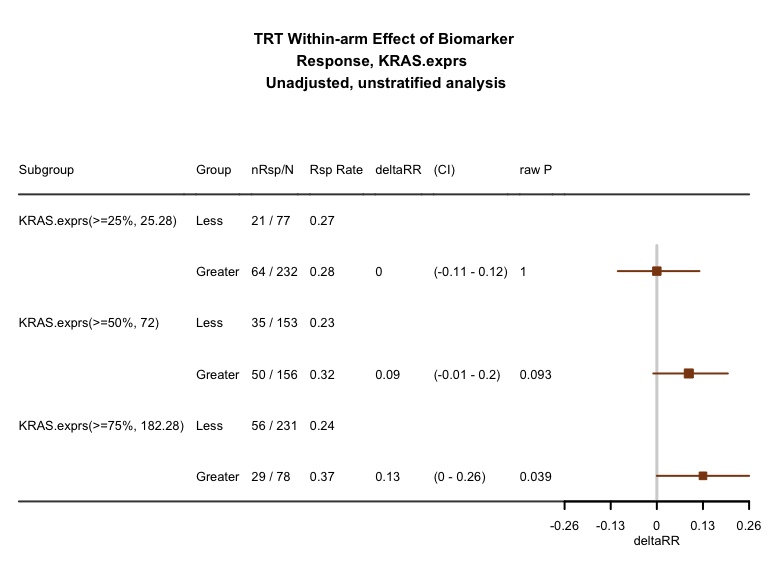

```r
input.trt <- subset(input, Arm=="TRT") ## Data with only trt samples
res.multicut.trt <- PlotTabForestBiomarker(data=input.trt,
                                  outcome.class=c("binary"),
                                  outcome.var=c("Response"),
                                  rsp.cat = TRUE,
                                  rsp.response = c("CR","PR"),
                                  rsp.nonresponse = c("SD", "PD","NON CR/PD","NE",NA),
                                  var="KRAS.exprs",
                                  var.class="numeric",
                                  percentile.cutoff=c(.25,.5,.75), main.prefix="TRT",
                                  greater=TRUE, less=FALSE)
```

The summary statistics shown in the forest plot is

deltaRR = [Response Rate in biomarker high] - [Response Rate in biomarker low]

To calculate the response rate, user needs to binarize the response classes into two classes.

Parameter () can be used to define levels to be considered as responder (non-responder). Patients whose response outcome don’t fall into these defined levels will be elminated from the analysis.

In both arms, we observe that patients with higher expression tend to have higher response rate. This indicates that in terms of response, KRAS.exprs shows prognostic trend.

#### 4.4.2.2 Seeking for predictive trend: cutoff exploration/selection

Similar to the example in section 4.1.3,

function also can be used for cutoff exploration.

```
## Covariate adjustment and stratification are not supported for binary outcome
```

```
## Some NAs in var column, will define the non NA entries as BEP
```

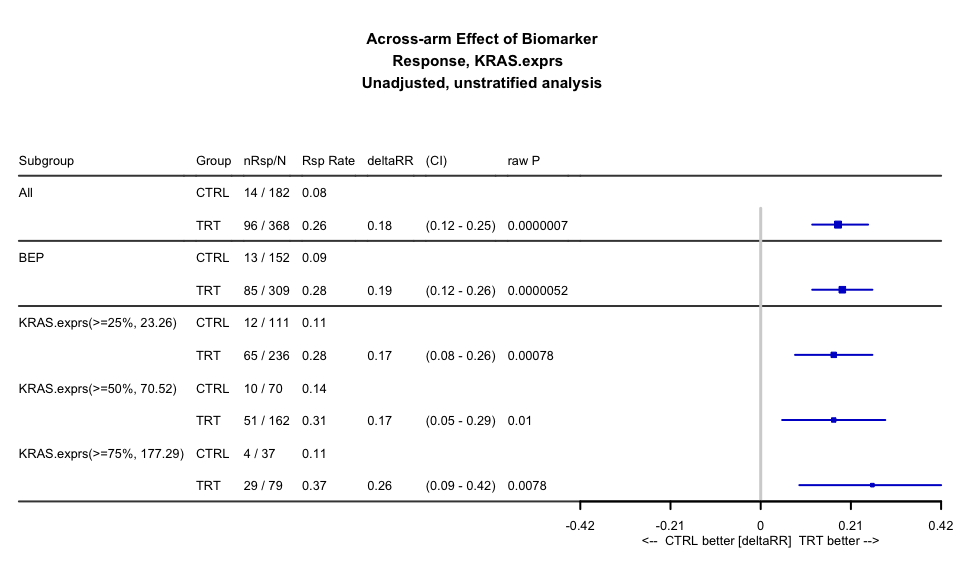

```r
res.multicut.2arm <- PlotTabForestBiomarker(data=input,
                                  outcome.class=c("binary"),
                                  outcome.var=c("Response"),
                                  trt = "Arm",
                                  rsp.cat = TRUE,
                                  rsp.response = c("CR","PR"),
                                  rsp.nonresponse = c("SD", "PD","NON CR/PD","NE",NA),
                                  var="KRAS.exprs",
                                  var.class="numeric",
                                  percentile.cutoff=c(.25,.5,.75),
                                  greater=TRUE, less=FALSE)
```

In across-arm analysis, for a given subgroup, the delta RR is calculated as [Response Rate in treatment] - [Response Rate in control]

From the figure above, we can observe that no matter where we set the biomarker cutoff, the biomarker high group always shows similar delta RR as the BEP delta RR (as well as full population delta RR)

We can further examine the predictive trend by looking at the within-bin analysis:

```
## Covariate adjustment and stratification are not supported for binary outcome
```

```
## Some NAs in var column, will define the non NA entries as BEP
```

```
## within.bin is TRUE, greater and less will be ignored
```

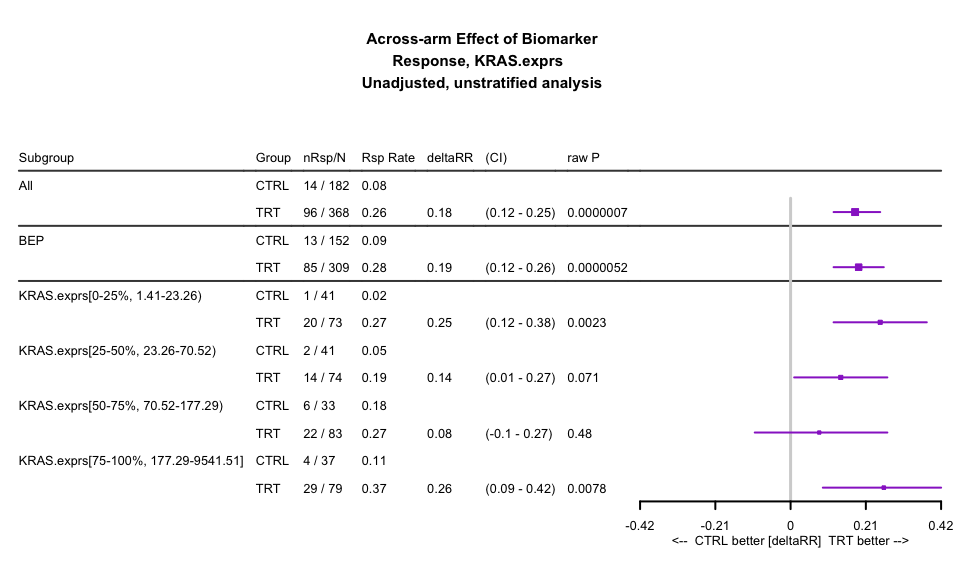

```r
res.multicut.2arm <- PlotTabForestBiomarker(data=input,
                                  outcome.class=c("binary"),
                                  outcome.var=c("Response"),
                                  trt = "Arm",
                                  rsp.cat = TRUE,
                                  rsp.response = c("CR","PR"),
                                  rsp.nonresponse = c("SD", "PD","NON CR/PD","NE",NA),
                                  var="KRAS.exprs",
                                  var.class="numeric",
                                  percentile.cutoff=c(.25,.5,.75),
                                  within.bin=TRUE)
```

This indicates that there is no clear predictive trend in terms of the response outcome - the result doesn’t show that the higher (lower) the expression, the more benefit in treatment arm compare to control arm.